# PML Course Project - Predicting Biceps Curl Quality of Execution

Nevena S Boyadzhiev

Sunday, August 24, 2014

# Background of the study

Using devices such as Jawbone Up, Nike FuelBand, and Fitbit makes it possible to collect a large amount of data about personal activity relatively inexpensively. These type of devices are part of the quantified self movement aiming to improve subjects’ health, to find patterns in their behavior, or because they enjoy playing with technology. One thing that people regularly measure is how much of a particular activity they do, but they rarely quantify how well they do it. In this project, the goal is to use data from Razor inertial measurement units (IMU) mounted on the belts, gloves, arm-bands, and dumbells of 6 participants. They were asked to perform Unilateral Dumbbell Biceps Curls in 5 different fashions: correctly (according to specifications) and incorrectly (in 4 different ways).

# Overview of the data

Before you start modelling, take a look at the data. Don’t forget to set your working directory and to download the training and testing data sets in it.

```r
library(ggplot2)
library(randomForest)
library(caret)
train <- read.csv("pml-training.csv")
str(train[,1:15])
```

```
## 'data.frame':    19622 obs. of  15 variables:
##  $ X                   : int  1 2 3 4 5 6 7 8 9 10 ...
##  $ user_name           : Factor w/ 6 levels "adelmo","carlitos",..: 2 2 2 2 2 2 2 2 2 2 ...
##  $ raw_timestamp_part_1: int  1323084231 1323084231 1323084231 1323084232 1323084232 1323084232 1323084232 1323084232 1323084232 1323084232 ...
##  $ raw_timestamp_part_2: int  788290 808298 820366 120339 196328 304277 368296 440390 484323 484434 ...
##  $ cvtd_timestamp      : Factor w/ 20 levels "02/12/2011 13:32",..: 9 9 9 9 9 9 9 9 9 9 ...
##  $ new_window          : Factor w/ 2 levels "no","yes": 1 1 1 1 1 1 1 1 1 1 ...
##  $ num_window          : int  11 11 11 12 12 12 12 12 12 12 ...
##  $ roll_belt           : num  1.41 1.41 1.42 1.48 1.48 1.45 1.42 1.42 1.43 1.45 ...
##  $ pitch_belt          : num  8.07 8.07 8.07 8.05 8.07 8.06 8.09 8.13 8.16 8.17 ...
##  $ yaw_belt            : num  -94.4 -94.4 -94.4 -94.4 -94.4 -94.4 -94.4 -94.4 -94.4 -94.4 ...
##  $ total_accel_belt    : int  3 3 3 3 3 3 3 3 3 3 ...
##  $ kurtosis_roll_belt  : Factor w/ 397 levels "","-0.016850",..: 1 1 1 1 1 1 1 1 1 1 ...
##  $ kurtosis_picth_belt : Factor w/ 317 levels "","-0.021887",..: 1 1 1 1 1 1 1 1 1 1 ...
##  $ kurtosis_yaw_belt   : Factor w/ 2 levels "","#DIV/0!": 1 1 1 1 1 1 1 1 1 1 ...
##  $ skewness_roll_belt  : Factor w/ 395 levels "","-0.003095",..: 1 1 1 1 1 1 1 1 1 1 ...
```

```r
summary(train$user_name)
```

```
##   adelmo carlitos  charles   eurico   jeremy    pedro
##     3892     3112     3536     3070     3402     2610
```

```r
summary(train$classe)
```

```
##    A    B    C    D    E
## 5580 3797 3422 3216 3607
```

```r
prop.table(table(train$user_name, train$classe),1)
```

```
##
##                 A      B      C      D      E
##   adelmo   0.2993 0.1994 0.1927 0.1323 0.1763
##   carlitos 0.2680 0.2217 0.1584 0.1562 0.1957
##   charles  0.2542 0.2107 0.1524 0.1816 0.2011
##   eurico   0.2818 0.1928 0.1593 0.1896 0.1765
##   jeremy   0.3460 0.1437 0.1917 0.1534 0.1652
##   pedro    0.2452 0.1935 0.1912 0.1797 0.1904
```

## Let’s do some exploratory analysis

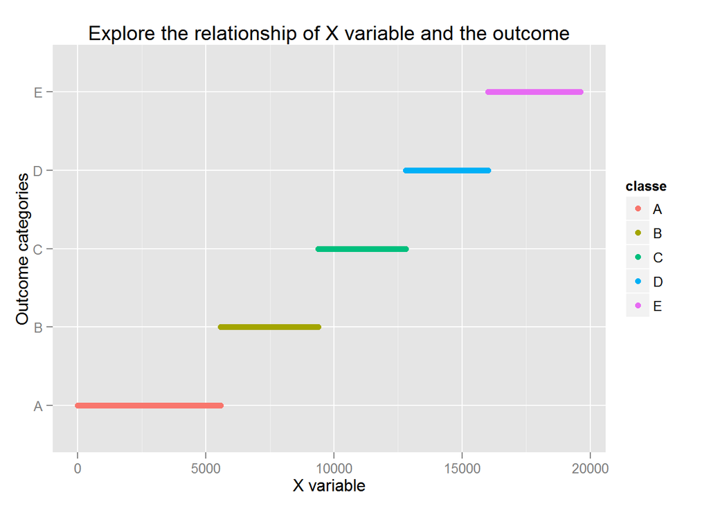

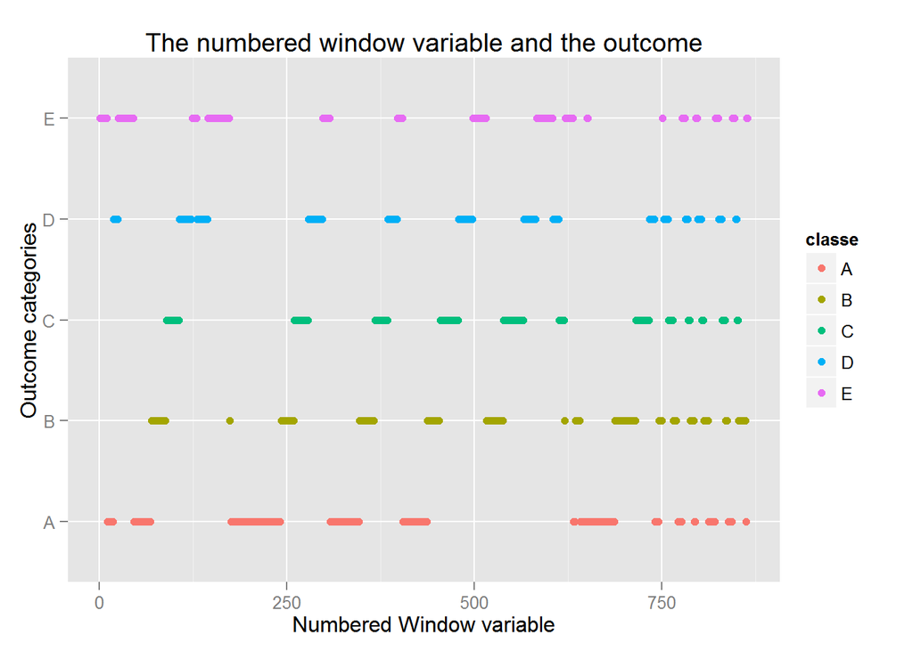

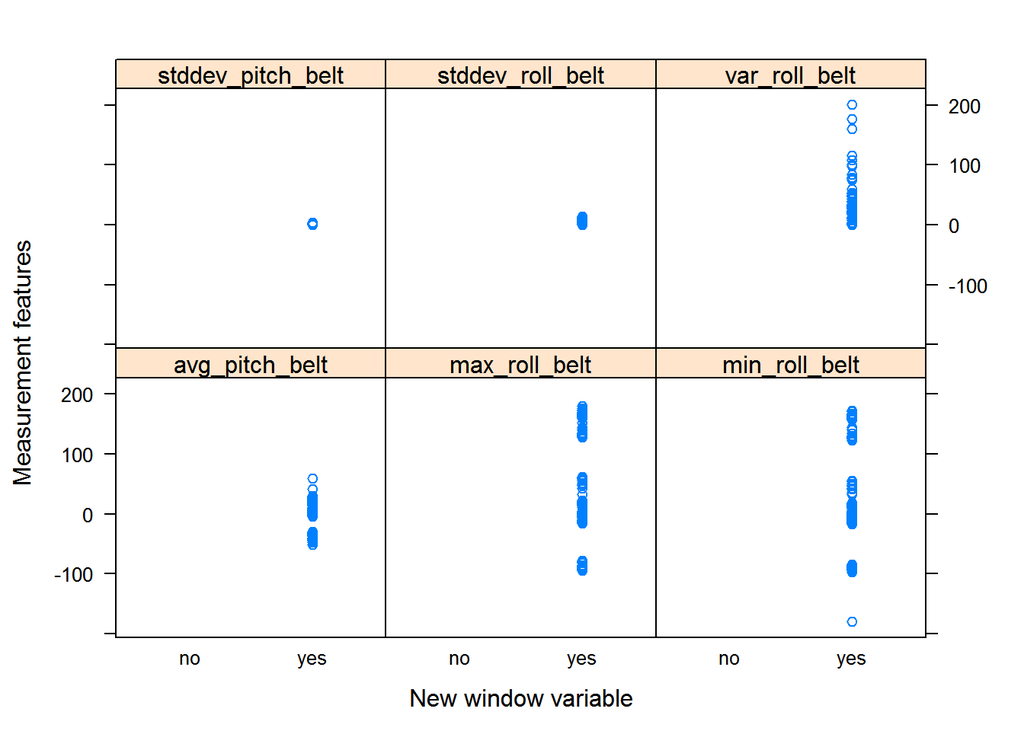

It is obvious that: 1.Variable X is directly correlated with the outcome. 2.It looks like the data was ordered by the outcome category and the observations were numbered using the X variable. 3.The categorical variable # of the window shows that the window frames were constructed based on the time series within which each participant performed the execises. 4.As each participant complied to the instructions of an experienced trainer, the two window variables cannot have a strong predictive value to an non-controlled set. 5.The new window variable is strongly correlated with many of the measurement features on the IMU readings.

```r
train$time <-as.POSIXct(train$raw_timestamp_part_1, origin="1970-01-01")
train <- train[,-c(1,3,4,5,7)]
```

### Exploratory analysis on features

Let’s explore all feature related to the Euler angles, and namely the roll, the pitch and the yaw of the four IMUs.

```r
yaw <- grep("yaw",names(train))
summary(train[,yaw])
```

```
##     yaw_belt      kurtosis_yaw_belt skewness_yaw_belt  max_yaw_belt
##  Min.   :-180.0          :19216            :19216            :19216
##  1st Qu.: -88.3   #DIV/0!:  406     #DIV/0!:  406     -1.1   :   30
##  Median : -13.0                                       -1.4   :   29
##  Mean   : -11.2                                       -1.2   :   26
##  3rd Qu.:  12.9                                       -0.9   :   24
##  Max.   : 179.0                                       -1.3   :   22
##                                                       (Other):  275
##   min_yaw_belt   amplitude_yaw_belt  avg_yaw_belt   stddev_yaw_belt
##         :19216          :19216      Min.   :-138    Min.   :  0
##  -1.1   :   30   #DIV/0!:   10      1st Qu.: -88    1st Qu.:  0
##  -1.4   :   29   0.00   :   12      Median :  -7    Median :  0
##  -1.2   :   26   0.0000 :  384      Mean   :  -9    Mean   :  1
##  -0.9   :   24                      3rd Qu.:  14    3rd Qu.:  1
##  -1.3   :   22                      Max.   : 174    Max.   :177
##  (Other):  275                      NA's   :19216   NA's   :19216
##   var_yaw_belt      yaw_arm         avg_yaw_arm    stddev_yaw_arm
##  Min.   :    0   Min.   :-180.00   Min.   :-173    Min.   :  0
##  1st Qu.:    0   1st Qu.: -43.10   1st Qu.: -29    1st Qu.:  3
##  Median :    0   Median :   0.00   Median :   0    Median : 17
##  Mean   :  107   Mean   :  -0.62   Mean   :   2    Mean   : 22
##  3rd Qu.:    0   3rd Qu.:  45.88   3rd Qu.:  38    3rd Qu.: 36
##  Max.   :31183   Max.   : 180.00   Max.   : 152    Max.   :177
##  NA's   :19216                     NA's   :19216   NA's   :19216
##   var_yaw_arm    kurtosis_yaw_arm skewness_yaw_arm  max_yaw_arm
##  Min.   :    0           :19216           :19216   Min.   : 4
##  1st Qu.:    7   #DIV/0! :   11   #DIV/0! :   11   1st Qu.:29
##  Median :  278   0.55844 :    2   -1.62032:    2   Median :34
##  Mean   : 1056   0.65132 :    2   0.55053 :    2   Mean   :35
##  3rd Qu.: 1295   -0.01548:    1   -0.00311:    1   3rd Qu.:41
##  Max.   :31345   -0.01749:    1   -0.00562:    1   Max.   :65
##  NA's   :19216   (Other) :  389   (Other) :  389   NA's   :19216
##   min_yaw_arm    amplitude_yaw_arm  yaw_dumbbell     kurtosis_yaw_dumbbell
##  Min.   : 1      Min.   : 0        Min.   :-150.87          :19216
##  1st Qu.: 8      1st Qu.:13        1st Qu.: -77.64   #DIV/0!:  406
##  Median :13      Median :22        Median :  -3.32
##  Mean   :15      Mean   :21        Mean   :   1.67
##  3rd Qu.:19      3rd Qu.:29        3rd Qu.:  79.64
##  Max.   :38      Max.   :52        Max.   : 154.95
##  NA's   :19216   NA's   :19216
```

[output cut: 25 more lines]

```
##         :19216               :19216          :19216
##  #DIV/0!:  406        #DIV/0!:   84   #DIV/0!:   84
##                       -1.2   :   32   -1.2   :   32
##                       -1.3   :   31   -1.3   :   31
##                       -1.4   :   24   -1.4   :   24
##                       -1.5   :   24   -1.5   :   24
##                       (Other):  211   (Other):  211
##  amplitude_yaw_forearm avg_yaw_forearm stddev_yaw_forearm var_yaw_forearm
##         :19216         Min.   :-155    Min.   :  0        Min.   :    0
##  #DIV/0!:   84         1st Qu.: -26    1st Qu.:  1        1st Qu.:    0
##  0.00   :  322         Median :   0    Median : 25        Median :  612
##                        Mean   :  18    Mean   : 45        Mean   : 4640
##                        3rd Qu.:  86    3rd Qu.: 86        3rd Qu.: 7368
##                        Max.   : 169    Max.   :198        Max.   :39009
##                        NA's   :19216   NA's   :19216      NA's   :19216
```

```r
remove_var1 <- c("kurtosis_yaw_belt","skewness_yaw_belt","amplitude_yaw_belt","kurtosis_yaw_dumbbell","skewness_yaw_dumbbell","amplitude_yaw_dumbbell","kurtosis_yaw_forearm","skewness_yaw_forearm","amplitude_yaw_forearm")
```

It looks like some features comprise only of zero or error values.Prepare to remove them. Do the same processing with the roll, pitch, accel, gyro and magnet features.

```r
roll <- grep("roll",names(train))
summary(train[,roll])
```

```
##    roll_belt     kurtosis_roll_belt skewness_roll_belt
##  Min.   :-28.9            :19216             :19216
##  1st Qu.:  1.1   #DIV/0!  :   10    #DIV/0!  :    9
##  Median :113.0   -1.908453:    2    0.000000 :    4
##  Mean   : 64.4   -0.016850:    1    0.422463 :    2
##  3rd Qu.:123.0   -0.021024:    1    -0.003095:    1
##  Max.   :162.0   -0.025513:    1    -0.010002:    1
##                  (Other)  :  391    (Other)  :  389
##  skewness_roll_belt.1 max_roll_belt   min_roll_belt   amplitude_roll_belt
##           :19216      Min.   :-94     Min.   :-180    Min.   :  0
##  #DIV/0!  :   32      1st Qu.:-88     1st Qu.: -88    1st Qu.:  0
##  0.000000 :    4      Median : -5     Median :  -8    Median :  1
##  -2.156553:    3      Mean   : -7     Mean   : -10    Mean   :  4
##  -3.072669:    3      3rd Qu.: 18     3rd Qu.:   9    3rd Qu.:  2
##  -6.324555:    3      Max.   :180     Max.   : 173    Max.   :360
##  (Other)  :  361      NA's   :19216   NA's   :19216   NA's   :19216
##  avg_roll_belt   stddev_roll_belt var_roll_belt      roll_arm
##  Min.   :-27     Min.   : 0       Min.   :  0     Min.   :-180.0
##  1st Qu.:  1     1st Qu.: 0       1st Qu.:  0     1st Qu.: -31.8
##  Median :116     Median : 0       Median :  0     Median :   0.0
##  Mean   : 68     Mean   : 1       Mean   :  8     Mean   :  17.8
##  3rd Qu.:123     3rd Qu.: 1       3rd Qu.:  0     3rd Qu.:  77.3
##  Max.   :157     Max.   :14       Max.   :201     Max.   : 180.0
##  NA's   :19216   NA's   :19216    NA's   :19216
##   avg_roll_arm   stddev_roll_arm  var_roll_arm   kurtosis_roll_arm
##  Min.   :-167    Min.   :  0     Min.   :    0           :19216
##  1st Qu.: -38    1st Qu.:  1     1st Qu.:    2   #DIV/0! :   78
##  Median :   0    Median :  6     Median :   33   -0.02438:    1
##  Mean   :  13    Mean   : 11     Mean   :  417   -0.04190:    1
##  3rd Qu.:  76    3rd Qu.: 15     3rd Qu.:  223   -0.05051:    1
##  Max.   : 163    Max.   :162     Max.   :26232   -0.05695:    1
##  NA's   :19216   NA's   :19216   NA's   :19216   (Other) :  324
##  skewness_roll_arm  max_roll_arm    min_roll_arm   amplitude_roll_arm
##          :19216    Min.   :-73     Min.   :-89     Min.   :  0
##  #DIV/0! :   77    1st Qu.:  0     1st Qu.:-42     1st Qu.:  5
##  -0.00051:    1    Median :  5     Median :-22     Median : 28
##  -0.00696:    1    Mean   : 11     Mean   :-21     Mean   : 32
##  -0.01884:    1    3rd Qu.: 27     3rd Qu.:  0     3rd Qu.: 51
##  -0.03359:    1    Max.   : 86     Max.   : 66     Max.   :120
##  (Other) :  325    NA's   :19216   NA's   :19216   NA's   :19216
```

[output cut: 33 more lines]

```
##  Min.   :-67      Min.   :-72      Min.   :  0            Min.   :-177
##  1st Qu.:  0      1st Qu.: -6      1st Qu.:  1            1st Qu.:  -1
##  Median : 27      Median :  0      Median : 18            Median :  11
##  Mean   : 24      Mean   :  0      Mean   : 25            Mean   :  33
##  3rd Qu.: 46      3rd Qu.: 12      3rd Qu.: 40            3rd Qu.: 107
##  Max.   : 90      Max.   : 62      Max.   :126            Max.   : 177
##  NA's   :19216    NA's   :19216    NA's   :19216          NA's   :19216
##  stddev_roll_forearm var_roll_forearm
##  Min.   :  0         Min.   :    0
##  1st Qu.:  0         1st Qu.:    0
##  Median :  8         Median :   64
##  Mean   : 42         Mean   : 5274
##  3rd Qu.: 85         3rd Qu.: 7289
##  Max.   :179         Max.   :32102
##  NA's   :19216       NA's   :19216
```

```r
remove_var2<- c("kurtosis_roll_belt","skewness_roll_belt","skewness_roll_belt.1",
                "kurtosis_roll_arm","skewness_roll_arm","kurtosis_roll_dumbbell",
      "skewness_roll_dumbbell","kurtosis_roll_forearm","skewness_roll_forearm")

pitch <- grep("pitch",names(train))
summary(train[,pitch])
```

```
##    pitch_belt     min_pitch_belt  amplitude_pitch_belt avg_pitch_belt
##  Min.   :-55.80   Min.   : 0      Min.   : 0           Min.   :-51
##  1st Qu.:  1.76   1st Qu.: 3      1st Qu.: 1           1st Qu.:  2
##  Median :  5.28   Median :16      Median : 1           Median :  5
##  Mean   :  0.31   Mean   :11      Mean   : 2           Mean   :  1
##  3rd Qu.: 14.90   3rd Qu.:17      3rd Qu.: 2           3rd Qu.: 16
##  Max.   : 60.30   Max.   :23      Max.   :12           Max.   : 60
##                   NA's   :19216   NA's   :19216        NA's   :19216
##  stddev_pitch_belt var_pitch_belt    pitch_arm      avg_pitch_arm
##  Min.   :0         Min.   : 0      Min.   :-88.80   Min.   :-82
##  1st Qu.:0         1st Qu.: 0      1st Qu.:-25.90   1st Qu.:-23
##  Median :0         Median : 0      Median :  0.00   Median :  0
##  Mean   :1         Mean   : 1      Mean   : -4.61   Mean   : -5
##  3rd Qu.:1         3rd Qu.: 0      3rd Qu.: 11.20   3rd Qu.:  8
##  Max.   :4         Max.   :16      Max.   : 88.50   Max.   : 76
##  NA's   :19216     NA's   :19216                    NA's   :19216
##  stddev_pitch_arm var_pitch_arm   skewness_pitch_arm min_pitch_arm
##  Min.   : 0       Min.   :   0            :19216     Min.   :-180
##  1st Qu.: 2       1st Qu.:   3    #DIV/0! :   80     1st Qu.: -73
##  Median : 8       Median :  66    -0.00184:    1     Median : -34
##  Mean   :10       Mean   : 196    -0.01185:    1     Mean   : -34
##  3rd Qu.:16       3rd Qu.: 267    -0.01247:    1     3rd Qu.:   0
##  Max.   :43       Max.   :1885    -0.02063:    1     Max.   : 152
##  NA's   :19216    NA's   :19216   (Other) :  322     NA's   :19216
##  amplitude_pitch_arm pitch_dumbbell   skewness_pitch_dumbbell
##  Min.   :  0         Min.   :-149.6          :19216
##  1st Qu.: 10         1st Qu.: -40.9   -0.2328:    2
##  Median : 55         Median : -21.0   -0.3521:    2
##  Mean   : 70         Mean   : -10.8   -0.7036:    2
##  3rd Qu.:115         3rd Qu.:  17.5   0.1090 :    2
##  Max.   :360         Max.   : 149.4   1.0326 :    2
##  NA's   :19216                        (Other):  396
##  min_pitch_dumbbell amplitude_pitch_dumbbell avg_pitch_dumbbell
##  Min.   :-147       Min.   :  0              Min.   :-71
##  1st Qu.: -92       1st Qu.: 17              1st Qu.:-42
##  Median : -66       Median : 42              Median :-20
##  Mean   : -33       Mean   : 66              Mean   :-12
##  3rd Qu.:  21       3rd Qu.:100              3rd Qu.: 13
##  Max.   : 121       Max.   :274              Max.   : 94
##  NA's   :19216      NA's   :19216            NA's   :19216
```

[output cut: 9 more lines]

```
##         :19216          Min.   :-180      Min.   :  0
##  #DIV/0!:   85          1st Qu.:-175      1st Qu.:  2
##  0.0000 :    4          Median : -61      Median : 84
##  -0.6992:    2          Mean   : -58      Mean   :139
##  -0.0113:    1          3rd Qu.:   0      3rd Qu.:350
##  -0.0131:    1          Max.   : 167      Max.   :360
##  (Other):  313          NA's   :19216     NA's   :19216
##  avg_pitch_forearm stddev_pitch_forearm var_pitch_forearm
##  Min.   :-68       Min.   : 0           Min.   :   0
##  1st Qu.:  0       1st Qu.: 0           1st Qu.:   0
##  Median : 12       Median : 6           Median :  30
##  Mean   : 12       Mean   : 8           Mean   : 140
##  3rd Qu.: 28       3rd Qu.:13           3rd Qu.: 166
##  Max.   : 72       Max.   :48           Max.   :2280
##  NA's   :19216     NA's   :19216        NA's   :19216
```

```r
accel <- grep("accel",names(train))
summary(train[,accel])
```

```
##  total_accel_belt var_total_accel_belt  accel_belt_x      accel_belt_y
##  Min.   : 0.0     Min.   : 0           Min.   :-120.00   Min.   :-69.0
##  1st Qu.: 3.0     1st Qu.: 0           1st Qu.: -21.00   1st Qu.:  3.0
##  Median :17.0     Median : 0           Median : -15.00   Median : 35.0
##  Mean   :11.3     Mean   : 1           Mean   :  -5.59   Mean   : 30.1
##  3rd Qu.:18.0     3rd Qu.: 0           3rd Qu.:  -5.00   3rd Qu.: 61.0
##  Max.   :29.0     Max.   :16           Max.   :  85.00   Max.   :164.0
##                   NA's   :19216
##   accel_belt_z    total_accel_arm var_accel_arm    accel_arm_x
##  Min.   :-275.0   Min.   : 1.0    Min.   :  0     Min.   :-404.0
##  1st Qu.:-162.0   1st Qu.:17.0    1st Qu.:  9     1st Qu.:-242.0
##  Median :-152.0   Median :27.0    Median : 41     Median : -44.0
##  Mean   : -72.6   Mean   :25.5    Mean   : 53     Mean   : -60.2
##  3rd Qu.:  27.0   3rd Qu.:33.0    3rd Qu.: 76     3rd Qu.:  84.0
##  Max.   : 105.0   Max.   :66.0    Max.   :332     Max.   : 437.0
##                                   NA's   :19216
##   accel_arm_y      accel_arm_z     total_accel_dumbbell var_accel_dumbbell
##  Min.   :-318.0   Min.   :-636.0   Min.   : 0.0         Min.   :  0
##  1st Qu.: -54.0   1st Qu.:-143.0   1st Qu.: 4.0         1st Qu.:  0
##  Median :  14.0   Median : -47.0   Median :10.0         Median :  1
##  Mean   :  32.6   Mean   : -71.2   Mean   :13.7         Mean   :  4
##  3rd Qu.: 139.0   3rd Qu.:  23.0   3rd Qu.:19.0         3rd Qu.:  3
##  Max.   : 308.0   Max.   : 292.0   Max.   :58.0         Max.   :230
##                                                         NA's   :19216
##  accel_dumbbell_x accel_dumbbell_y accel_dumbbell_z total_accel_forearm
##  Min.   :-419.0   Min.   :-189.0   Min.   :-334.0   Min.   :  0.0
##  1st Qu.: -50.0   1st Qu.:  -8.0   1st Qu.:-142.0   1st Qu.: 29.0
##  Median :  -8.0   Median :  41.5   Median :  -1.0   Median : 36.0
##  Mean   : -28.6   Mean   :  52.6   Mean   : -38.3   Mean   : 34.7
##  3rd Qu.:  11.0   3rd Qu.: 111.0   3rd Qu.:  38.0   3rd Qu.: 41.0
##  Max.   : 235.0   Max.   : 315.0   Max.   : 318.0   Max.   :108.0
##
##  var_accel_forearm accel_forearm_x  accel_forearm_y accel_forearm_z
##  Min.   :  0       Min.   :-498.0   Min.   :-632    Min.   :-446.0
##  1st Qu.:  7       1st Qu.:-178.0   1st Qu.:  57    1st Qu.:-182.0
##  Median : 21       Median : -57.0   Median : 201    Median : -39.0
##  Mean   : 34       Mean   : -61.7   Mean   : 164    Mean   : -55.3
##  3rd Qu.: 51       3rd Qu.:  76.0   3rd Qu.: 312    3rd Qu.:  26.0
##  Max.   :173       Max.   : 477.0   Max.   : 923    Max.   : 291.0
##  NA's   :19216
```

```r
gyro <- grep("gyro",names(train))
summary(train[,gyro])
```

```
##   gyros_belt_x      gyros_belt_y      gyros_belt_z     gyros_arm_x
##  Min.   :-1.0400   Min.   :-0.6400   Min.   :-1.460   Min.   :-6.370
##  1st Qu.:-0.0300   1st Qu.: 0.0000   1st Qu.:-0.200   1st Qu.:-1.330
##  Median : 0.0300   Median : 0.0200   Median :-0.100   Median : 0.080
##  Mean   :-0.0056   Mean   : 0.0396   Mean   :-0.130   Mean   : 0.043
##  3rd Qu.: 0.1100   3rd Qu.: 0.1100   3rd Qu.:-0.020   3rd Qu.: 1.570
##  Max.   : 2.2200   Max.   : 0.6400   Max.   : 1.620   Max.   : 4.870
##   gyros_arm_y      gyros_arm_z    gyros_dumbbell_x  gyros_dumbbell_y
##  Min.   :-3.440   Min.   :-2.33   Min.   :-204.00   Min.   :-2.10
##  1st Qu.:-0.800   1st Qu.:-0.07   1st Qu.:  -0.03   1st Qu.:-0.14
##  Median :-0.240   Median : 0.23   Median :   0.13   Median : 0.03
##  Mean   :-0.257   Mean   : 0.27   Mean   :   0.16   Mean   : 0.05
##  3rd Qu.: 0.140   3rd Qu.: 0.72   3rd Qu.:   0.35   3rd Qu.: 0.21
##  Max.   : 2.840   Max.   : 3.02   Max.   :   2.22   Max.   :52.00
##  gyros_dumbbell_z gyros_forearm_x   gyros_forearm_y  gyros_forearm_z
##  Min.   : -2.4    Min.   :-22.000   Min.   : -7.02   Min.   : -8.09
##  1st Qu.: -0.3    1st Qu.: -0.220   1st Qu.: -1.46   1st Qu.: -0.18
##  Median : -0.1    Median :  0.050   Median :  0.03   Median :  0.08
##  Mean   : -0.1    Mean   :  0.158   Mean   :  0.08   Mean   :  0.15
##  3rd Qu.:  0.0    3rd Qu.:  0.560   3rd Qu.:  1.62   3rd Qu.:  0.49
##  Max.   :317.0    Max.   :  3.970   Max.   :311.00   Max.   :231.00
```

```r
magnet <- grep("magnet",names(train))
summary(train[,magnet])
```

```
##  magnet_belt_x   magnet_belt_y magnet_belt_z   magnet_arm_x
##  Min.   :-52.0   Min.   :354   Min.   :-623   Min.   :-584
##  1st Qu.:  9.0   1st Qu.:581   1st Qu.:-375   1st Qu.:-300
##  Median : 35.0   Median :601   Median :-320   Median : 289
##  Mean   : 55.6   Mean   :594   Mean   :-346   Mean   : 192
##  3rd Qu.: 59.0   3rd Qu.:610   3rd Qu.:-306   3rd Qu.: 637
##  Max.   :485.0   Max.   :673   Max.   : 293   Max.   : 782
##   magnet_arm_y   magnet_arm_z  magnet_dumbbell_x magnet_dumbbell_y
##  Min.   :-392   Min.   :-597   Min.   :-643      Min.   :-3600
##  1st Qu.:  -9   1st Qu.: 131   1st Qu.:-535      1st Qu.:  231
##  Median : 202   Median : 444   Median :-479      Median :  311
##  Mean   : 157   Mean   : 306   Mean   :-328      Mean   :  221
##  3rd Qu.: 323   3rd Qu.: 545   3rd Qu.:-304      3rd Qu.:  390
##  Max.   : 583   Max.   : 694   Max.   : 592      Max.   :  633
##  magnet_dumbbell_z magnet_forearm_x magnet_forearm_y magnet_forearm_z
##  Min.   :-262.0    Min.   :-1280    Min.   :-896     Min.   :-973
##  1st Qu.: -45.0    1st Qu.: -616    1st Qu.:   2     1st Qu.: 191
##  Median :  13.0    Median : -378    Median : 591     Median : 511
##  Mean   :  46.1    Mean   : -313    Mean   : 380     Mean   : 394
##  3rd Qu.:  95.0    3rd Qu.:  -73    3rd Qu.: 737     3rd Qu.: 653
##  Max.   : 452.0    Max.   :  672    Max.   :1480     Max.   :1090
```

```r
remove_vars<- c(remove_var1, remove_var2)
remove <- names(train) %in% remove_vars
train <- train[!remove]
```